# Siland: Spatial Influence of landscape

Florence Carpentier and Olivier Martin

2023-03-30

## Introduction

The package *siland* aims to estimate the effects of landscape and local variables on a measurement of interest. The method enable to estimate effect intensities but also the scale of the effect for landscape variables, without any a priori. The method is based on estimation of Spatial Influence Function (SIF).The SIF function describes how the influence of a pixel/cell of a landscape variable is spatially distributed. We assume that the influence is maximal at the pixel location and decreases with the distance. The decrease is parametrised by one parameter which corresponds to the mean distance for the SIF.

It is worth noting that the method simultaneously estimate intensities of effect and scales of effect using a numerical likelihood maximisation procedure. This means that the mean distances of the SIFs are not given by the user but estimated for each landscape variable.

*siland* package is designed to be a user-friendly tool: data format are commonly used (data.frame and shape files from GIS data), model expression is simple (classical formula as lm expression), various outputs are very easily computed: summary of estimates and tests, graphical maps of effects and graphical checking of likelihood maximisation. Based on linear model, it includes numerous extensions of linear model: interactions, random effects, GLM (binomial and poisson). It is also possible to build multiannual model. We detailed hereafter some examples of simple use of the *siland* package. (More details about the method can be found in https://www.biorxiv.org/content/10.1101/692566v1).

## A first example

### Data

*siland* package requires two data objects:

- **data.frame of located observations** . *Data locations* have to be indicated in *columns “X” and “Y”*. The variable of interest as possible local variables are also included here.
- **sf object** containing description of landscape variables. It can be created using the `st_read` function of the package `sf`. For instance if your GIS data (in shp format) are in the *FILE* file, named *NAME* (i.e.FILE contains NAME.shp, NAME.dbf,…), you can easily import your data in landdata using the command:

```r
landdata=st_read(dsn = "FILE",layer="NAME")
```

Here, we use the objects dataSiland and landSiland, included in *siland* package. You can load data using the `data` command.

```r
library(siland)
## Le chargement a nécessité le package : sf
## Linking to GEOS 3.9.3, GDAL 3.5.2, PROJ 8.2.1; sf_use_s2() is TRUE
data(dataSiland)
data(landSiland)
```

*dataSiland* is a data.frame with columns: “obs”, variable of interest and “x1” variable, a continuous local variable. The “Id” column indicates the identification number of the plots where observations were made. *landSiland* is an object of class sf where landscape is characterised by two features named L1 and L2. Landscape is described by polygons. For each polygon, L1 is equal to 1 if the polygon is of type L1, 0 otherwise (so is it for L2).

```r
str(dataSiland)
```

```
## 'data.frame':    100 obs. of  5 variables:
##  $ X  : num  8508 8508 6578 6578 1904 ...
##  $ Y  : num  7177 7177 3829 3829 1555 ...
##  $ x1 : num  6.23 6.23 -3.91 -3.91 7.55 ...
##  $ Id : num  1 1 2 2 3 3 4 4 5 5 ...
##  $ obs: num  18.34 18.17 1.95 1.09 6.81 ...
```

```r
str(landSiland)
```

```
## Classes 'sf' and 'data.frame':   4884 obs. of  3 variables:
##  $ L1      : num  0 0 0 0 0 0 0 0 0 0 ...
##  $ L2      : num  0 1 0 0 0 0 0 0 1 0 ...
##  $ geometry:sfc_MULTIPOLYGON of length 4884; first list element: List of 1
##   ..$ :List of 1
##   .. ..$ : num [1:8, 1:2] 5993 5999 5978 5977 5975 ...
##   ..- attr(*, "class")= chr [1:3] "XY" "MULTIPOLYGON" "sfg"
##  - attr(*, "sf_column")= chr "geometry"
##  - attr(*, "agr")= Factor w/ 3 levels "constant","aggregate",..: NA NA
##   ..- attr(*, "names")= chr [1:2] "L1" "L2"
```

You can look at spatial configuration of the loaded data using the following commands :

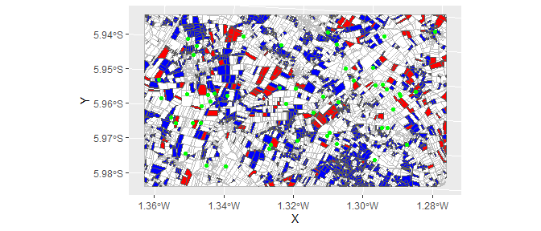

```r
library(ggplot2)
library(sf)
L1pol=st_geometry(landSiland[landSiland$L1==1,])#extract an sf object with only polygons of type L1
L2pol=st_geometry(landSiland[landSiland$L2==1,])#extract an sf object with only polygons of type L2
ggplot(landSiland)+
  geom_sf(colour="grey",fill="white")+
  geom_sf(data=L1pol,fill="red")+
  geom_sf(data=L2pol,fill="blue")+
  geom_point(data=dataSiland, aes(X,Y),col="green")
```

### Spatial Influence Function approach : `siland()`

Estimations for landscape and local variables are based on discretization with cells (or pixels) of the landscape. This discretization is called a raster. Each unit (cell/pixel) of landscape variable has an influence which is maximal at its location and decreases as the distance increases. The decrease of this influence is described by a spatial influence function (SIF). For modelling a given landscape variable influence, we consider every cell where the landscape variable is distributed, and computed its influence by summing spatial influence of all cells. The spatial influence of a cell is determined by its intensity (negative or positive) and its SIF, which is a density function described by its mean distance (in *siland* package). The *siland* package allows to estimate the intensity of effect and the scale of effects i.e. here the mean distance of SIF. Estimating effects of the local variable x1 and landscape variables L1 and L2 on the variable of interest obs can be done with the command `siland()` (the argument `wd` is presented below):

```r
res=siland(obs~x1+L1+L2,land=landSiland,data=dataSiland,wd=30)
## Local variables: x1
## Landscape variables: L1 L2
## Model: obs ~ x1 + L1 + L2
## Model0: obs ~ x1
```

```r
res
## Model: obs ~ x1 + L1 + L2
##
## Landscape variables: L1 L2
##
## Coefficients:
## (Intercept)          x1          L1          L2      SIF.L1      SIF.L2
##       1.249       0.085     -11.933      29.400     113.489     190.179
##
## standard error: 1.123119
## AIC: 316.93  AIC (no landscape): 619.37
## (No landscape effect) p-value: <1e-16
```

Parameter estimates and tests can be obtained using the command `summary`:

```r
summary(res)
## SIF parameters:
##   SIF.L1   SIF.L2
## 113.4894 190.1787
##
## -- Tests are given conditionally to the best SIF parameters --
##
## Call:
## obs ~ x1 + L1 + L2
##
## Deviance Residuals:
##      Min        1Q    Median        3Q       Max
## -2.97160  -0.83136   0.02424   0.66240   2.68791
##
## Coefficients:
##              Estimate Std. Error t value Pr(>|t|)
## (Intercept)   1.24886    0.17868   6.989 3.65e-10 ***
## x1            0.08501    0.01861   4.568 1.46e-05 ***
## L1          -11.93331    0.97165 -12.281  < 2e-16 ***
## L2           29.40033    0.68737  42.772  < 2e-16 ***
## ---
## Signif. codes:  0 '***' 0.001 '**' 0.01 '*' 0.05 '.' 0.1 ' ' 1
##
## (Dispersion parameter for gaussian family taken to be 1.261396)
##
##     Null deviance: 2965.92  on 99  degrees of freedom
## Residual deviance:  121.09  on 96  degrees of freedom
## AIC: 312.93
##
## Number of Fisher Scoring iterations: 2
```

Note that p.values are given conditionally to estimated parameters for SIFs.

The command `plotsiland.sif` gives a representation of the estimated SIF for landscape variables. The shape of the SIF could be “exponential”, “gaussian” or “uniform”. The shape can be defined with the argument sif in the function `siland()` and is exponential by default. The function `plotsiland.sif()` allows to displays the estimated SIFs.

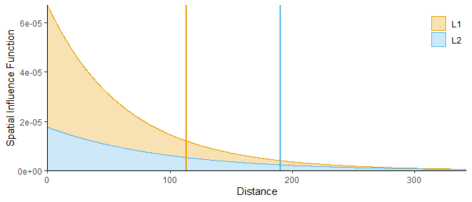

```r
plotsiland.sif(res)
```

The command `plotsiland.land` gives map of effects of the landscape. By default, it gives the global contribution of all landscape variables:

```r
plotsiland.land(x=res,land=landSiland,data=dataSiland)
```

[output not shown]

One can obtain a map for a specific landscape variable by specifying its number with the argument `var`:

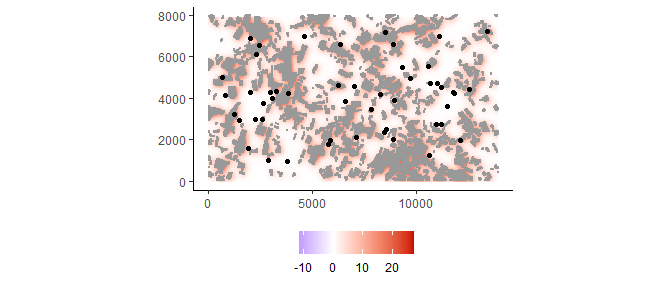

```r
plotsiland.land(x=res,land=landSiland,data=dataSiland,var=2)
## Distance computing...
## Contribution computing...
```

#### Visual check of likelihood maximisation procedure.

As with all numerical maximization procedures, optimization problems may arise. The function `siland.lik()` allows to point out possible problems of optimization.

```r
likres=siland.lik(res,land= landSiland,data=dataSiland,varnames=c("L1","L2"))
## Likelihood computing for  L1
## Likelihood computing for  L2
```

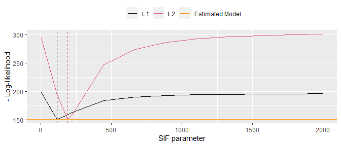

```r
likres
```

#### siland() arguments

- The argument `wd` indicates the mesh size used to construct spatial unit (cells/pixels) of landscape variable. In fact, landscape variable described as polygon are discretized on grid during the procedure estimation (like raster). The choice of wd is a tradeoff between computing precision and computing time (and memory size). The smallest `wd` is, the better are the precision but the longer the computing time is (and the larger the required memory size is). It is worth to note that estimated parameters can be very sensitive to this mesh size. **To obtain a reliable estimation, we recommand to ensure, after the estimation procedure, that `wd` size is at least three times smaller than the smallest estimated SIF.** If not, it is recommended to proceed with a new estimation with a smaller `wd` size.
- The argument `maxD` corresponds to a radius. For each observation, only pixels with a distance less than maxD are used for estimation. For a given observation, pixels with a distance greater than maxD have in fact a very low intensity and can be ignored. **To obtain a reliable estimation, we recommand to ensure, after the estimation procedure, that `maxD` size is at least three times greater than the greatest estimated SIF.**
- The argument `border` indicates whether an observation receives the spatial influence of cells belonging to the same plot (i.e. the plot where the observation was made). If `border=T`, its receives influence only from the border of the plot (so no influence from the cells of the plot). By default, `border = F` (all cells are considered). `border` is a vector that defines if `border` is True or False for each landscape variable. If `border=T` (resp. `border=F`) then the argument `border` is set to True (resp. False) for all landscape variables.
- The argument `sif` defines the family function of SIF, i.e. the form of decrease for the landscape influence. The family can be `exponential`, `gaussian`, or `uniform`. If influence is uniform, it implies that there is no decrease of influence and influence is uniform around each pixel of the raster. Note that all landscape variables have the same form.

### Mixed model

Random effect can be included using the syntax `(1| )`. Note that only local effect are concerned.

```r
res2=siland(obs~x1+L1+L2+(1|Id),land=landSiland,data=dataSiland,wd=30)
## Local variables: x1 Id
## Landscape variables: L1 L2
## Model: obs ~ x1 + L1 + L2 + (1 | Id)
## Model0: obs ~ x1 + (1 | Id)
```

```r
summary(res2)
## SIF parameters:
##   SIF.L1   SIF.L2
## 113.4894 190.1787
##
## -- Tests are given conditionally to the best SIF parameters --
## Linear mixed model fit by maximum likelihood  ['lmerMod']
##
##      AIC      BIC   logLik deviance df.resid
##    314.7    330.3   -151.4    302.7       94
##
## Scaled residuals:
##      Min       1Q   Median       3Q      Max
## -2.62434 -0.73048  0.01841  0.59069  2.34981
##
## Random effects:
##  Groups   Name        Variance Std.Dev.
##  Id       (Intercept) 0.080    0.2828
##  Residual             1.131    1.0635
## Number of obs: 100, groups:  Id, 50
##
## Fixed effects:
##              Estimate Std. Error t value
## (Intercept)   1.24886    0.18076   6.909
## x1            0.08501    0.01883   4.515
## L1          -11.93331    0.98297 -12.140
## L2           29.40033    0.69537  42.280
##
## Correlation of Fixed Effects:
##    (Intr) x1     L1
## x1  0.201
## L1 -0.373 -0.107
## L2 -0.702 -0.252  0.055
```

### Non gaussian model

To consider distributions of the variable of interest that differ from Gaussian, use the option `family` available in the `siland()` function. Family can be “gaussian”, “poisson” or “binomial” and the associated link function are identity, log and logit respectively.

### Model with interaction between local and landscape variables

Interaction between local and landscape variables using the syntax `:` or `*` (as well as localxlocal interaction). Interaction term modify the intensity of a landscape variable according to the local variable value. But the scale of effect of the landscape variable remains constant.

```r
#Model with main and interaction effect
res3=siland(obs~x1*L1+L2,land=landSiland,data=dataSiland,wd=30)
## Local variables: x1
## Landscape variables: L1 L2
## Model: obs ~ x1 * L1 + L2
## Model0: obs ~ x1
```

```r
res3
## Model: obs ~ x1 * L1 + L2
##
## Landscape variables: L1 L2
##
## Coefficients:
## (Intercept)          x1          L1          L2       x1:L1      SIF.L1
##       1.243       0.081     -11.999      29.377       0.100     110.550
##      SIF.L2
##     190.241
##
## standard error: 1.128036
## AIC: 318.75  AIC (no landscape): 619.37
## (No landscape effect) p-value: <1e-16
```

```r
res3.1=siland(obs~x1*L1+L2,land=landSiland,data=dataSiland,wd=30)
## Local variables: x1
## Landscape variables: L1 L2
## Model: obs ~ x1 * L1 + L2
## Model0: obs ~ x1
```

```r
res3.1
## Model: obs ~ x1 * L1 + L2
##
## Landscape variables: L1 L2
##
## Coefficients:
## (Intercept)          x1          L1          L2       x1:L1      SIF.L1
##       1.243       0.081     -11.999      29.377       0.100     110.550
##      SIF.L2
##     190.241
##
## standard error: 1.128036
## AIC: 318.75  AIC (no landscape): 619.37
## (No landscape effect) p-value: <1e-16
```

### Multiyear model and multisite model

It is possible to deal with data observed during several years, i.e. data associated with several landscapes with the function `siland`. The two data objects required are then : * a **list of** data.frames of located observations, one for each year. An important point is that **data.frames column names have to be exactly the same and ordered in the same way.** * a **list of** sf object containing a landscape description of each year.

Let us suppose we have two years of observations associated with two landscapes. Since the goal is only to show how to deal with such datasets, we take the same datastets for observations and for landscapes for the two years.

```r
landSilandY1=landSiland
landSilandY2=landSiland
#landSilandY is a list with the landscape for each year
landSilandY=list(year1=landSilandY1,year2=landSilandY2)
dataSilandY1=dataSiland
dataSilandY2=dataSiland
dataSilandY1$year=factor("2018")
dataSilandY2$year=factor("2019")
head(dataSilandY1)
```

```
##          X        Y     x1 Id       obs year
## 1 8507.824 7176.949  6.226  1 18.336417 2018
## 2 8507.824 7176.949  6.226  1 18.167951 2018
## 3 6577.630 3828.792 -3.906  2  1.950956 2018
## 4 6577.630 3828.792 -3.906  2  1.088552 2018
## 5 1904.231 1554.608  7.549  3  6.807977 2018
## 6 1904.231 1554.608  7.549  3  4.441390 2018
```

```r
head(dataSilandY2)
```

```
##          X        Y     x1 Id       obs year
## 1 8507.824 7176.949  6.226  1 18.336417 2019
## 2 8507.824 7176.949  6.226  1 18.167951 2019
## 3 6577.630 3828.792 -3.906  2  1.950956 2019
## 4 6577.630 3828.792 -3.906  2  1.088552 2019
## 5 1904.231 1554.608  7.549  3  6.807977 2019
## 6 1904.231 1554.608  7.549  3  4.441390 2019
```

```r
dataSilandY=list(year1=dataSilandY1,year2=dataSilandY2)
#dataSilandY is a list with the observed data for each year
resY=siland(obs~year+x1+L1+L2, land = landSilandY,data=dataSilandY,wd=30)
## Local variables: year x1
## Landscape variables: L1 L2
## Model: obs ~ year + x1 + L1 + L2
## Model0: obs ~ year + x1
resY
## Model: obs ~ year + x1 + L1 + L2
##
## Landscape variables: L1 L2
##
## Coefficients:
## (Intercept)    year2019          x1          L1          L2      SIF.L1
##       1.249       0.000       0.085     -11.933      29.400     113.489
##      SIF.L2
##     190.179
##
## standard error: 1.114446
## AIC: 621.85  AIC (no landscape): 1234.73
## (No landscape effect) p-value: <1e-16
```

```r
resY
## Model: obs ~ year + x1 + L1 + L2
##
## Landscape variables: L1 L2
##
## Coefficients:
## (Intercept)    year2019          x1          L1          L2      SIF.L1
##       1.249       0.000       0.085     -11.933      29.400     113.489
##      SIF.L2
##     190.179
##
## standard error: 1.114446
## AIC: 621.85  AIC (no landscape): 1234.73
## (No landscape effect) p-value: <1e-16
summary(resY)
## SIF parameters:
##   SIF.L1   SIF.L2
## 113.4894 190.1787
##
## -- Tests are given conditionally to the best SIF parameters --
##
## Call:
## obs ~ year + x1 + L1 + L2
##
## Deviance Residuals:
##      Min        1Q    Median        3Q       Max
## -2.97160  -0.83136   0.02424   0.66240   2.68791
##
## Coefficients:
##               Estimate Std. Error t value Pr(>|t|)
## (Intercept)  1.249e+00  1.481e-01   8.434  7.4e-15 ***
## year2019    -2.679e-15  1.576e-01   0.000        1
## x1           8.501e-02  1.306e-02   6.510  6.2e-10 ***
## L1          -1.193e+01  6.818e-01 -17.504  < 2e-16 ***
## L2           2.940e+01  4.823e-01  60.960  < 2e-16 ***
## ---
## Signif. codes:  0 '***' 0.001 '**' 0.01 '*' 0.05 '.' 0.1 ' ' 1
##
## (Dispersion parameter for gaussian family taken to be 1.241989)
##
##     Null deviance: 5931.84  on 199  degrees of freedom
## Residual deviance:  242.19  on 195  degrees of freedom
## AIC: 617.85
##
## Number of Fisher Scoring iterations: 2
```

It is possible to deal with multisite data, using the same procedure considering different sites instead of different years.

## Remarks

As for an object ot type GLM, functions AIC(), residuals() and fitted() are available. In fact, conditionnaly to the estimated buffers or SIFs, the fitted model is a GLM or a LMM (Linear Mixed Model) or a GLMM (Generalized Linear Mixed Model). So after an estimation, it is possible to analyse more precisely the estimated model with the object result stored in the output. Object result is an an object from glm() or lmer() or glmer() functions.

```r
summary(res$result)
```

```
##
## Call:
## glm(formula = model, family = family, data = newdata)
##
## Deviance Residuals:
##      Min        1Q    Median        3Q       Max
## -2.97160  -0.83136   0.02424   0.66240   2.68791
##
## Coefficients:
##              Estimate Std. Error t value Pr(>|t|)
## (Intercept)   1.24886    0.17868   6.989 3.65e-10 ***
## x1            0.08501    0.01861   4.568 1.46e-05 ***
## L1          -11.93331    0.97165 -12.281  < 2e-16 ***
## L2           29.40033    0.68737  42.772  < 2e-16 ***
## ---
## Signif. codes:  0 '***' 0.001 '**' 0.01 '*' 0.05 '.' 0.1 ' ' 1
##
## (Dispersion parameter for gaussian family taken to be 1.261396)
##
##     Null deviance: 2965.92  on 99  degrees of freedom
## Residual deviance:  121.09  on 96  degrees of freedom
## AIC: 312.93
##
## Number of Fisher Scoring iterations: 2
```

```r
BIC(res$result)
```

```
## [1] 325.9532
```

```r
fitted(res$result)[1:10]
```

```
##         1         2         3         4         5         6         7         8
## 17.515084 17.515084  1.931324  1.931324  6.116991  6.116991 -3.618455 -3.618455
##         9        10
##  2.579123  2.579123
```

```r
residuals(res$result)[1:10]
```

```
##           1           2           3           4           5           6
##  0.82133235  0.65286713  0.01963192 -0.84277194  0.69098527 -1.67560150
##           7           8           9          10
##  1.01085931 -1.20498043  0.12104466  1.27277387
```

```r
class(res$result)
```

```
## [1] "glm" "lm"
```

```r
class(res$result)
```

```
## [1] "glm" "lm"
```